# Week 4: Regression

Carole Voulgaris

9/10/2020

For this assignment, you’ll be using the following libraries, so make sure they’re installed ahead of time. I’ll be using the tidyverse library to recode my data.

```r
library(tidyverse)
library(jtools)
library(interactions)
library(knitr)
```

## Loading the data

Let’s start by loading and recoding the person-level dataset I created in Week 1

```r
ppl_data <- read_csv("people.csv") %>%
  mutate(tenure = case_when(
    TEN_label == "Owned with mortgage or loan (include home equity loans)" ~
      "1Own",
    TEN_label == "Owned free and clear" ~ "1Own",
    TEN_label == "Rented" ~ "Rent",
    TEN_label == "Occupied without payment of rent" ~ "Rent-free",
    TEN_label == "N/A (GQ/vacant)" ~ "Group quarters",
    TRUE ~ "Other")) %>%
  filter(WKHP > 0, PINCP > 0, JWMNP >0)
```

## Initial regression model

Here is a linear regression model predicting travel time to work, based on hours worked per week, income, tenure, and sex:

```r
model1 <- lm(JWMNP ~ WKHP + PINCP + tenure + SEX_label,
            data = ppl_data)

summary(model1)
```

```
##
## Call:
## lm(formula = JWMNP ~ WKHP + PINCP + tenure + SEX_label, data = ppl_data)
##
## Residuals:
##     Min      1Q  Median      3Q     Max
## -38.069 -13.599  -5.540   6.728 146.750
##
## Coefficients:
##                        Estimate Std. Error t value Pr(>|t|)
## (Intercept)           1.897e+01  2.356e-01  80.506  < 2e-16 ***
## WKHP                  1.610e-01  5.698e-03  28.251  < 2e-16 ***
## PINCP                 5.657e-06  9.644e-07   5.866 4.47e-09 ***
## tenureGroup quarters -1.119e+01  6.614e-01 -16.917  < 2e-16 ***
## tenureRent           -2.711e+00  1.489e-01 -18.202  < 2e-16 ***
## tenureRent-free      -3.617e+00  5.513e-01  -6.560 5.40e-11 ***
## SEX_labelMale         2.940e+00  1.369e-01  21.479  < 2e-16 ***
## ---
## Signif. codes:  0 '***' 0.001 '**' 0.01 '*' 0.05 '.' 0.1 ' ' 1
##
## Residual standard error: 22.46 on 115176 degrees of freedom
## Multiple R-squared:  0.0226, Adjusted R-squared:  0.02255
## F-statistic:   444 on 6 and 115176 DF,  p-value: < 2.2e-16
```

## A log transformation

The difference between earning $1,000 per year and $2,000 is probably more substantial than the difference between earning $50,000 per year and $51,000 per year. In the former case, income has increased by 100%, and in the latter, income has increased by 2%. When percentage increases are more relevant than absolute increases, that’s a clue that a log-transformed version of your variable might be appropriate. Does log-transforming income improve the model fit?

```r
model2 <- lm(JWMNP ~ WKHP + log(PINCP) + tenure + SEX_label,
            data = ppl_data)

summary(model2)
```

```
##
## Call:
## lm(formula = JWMNP ~ WKHP + log(PINCP) + tenure + SEX_label,
##     data = ppl_data)
##
## Residuals:
##     Min      1Q  Median      3Q     Max
## -36.644 -13.581  -5.336   6.593 147.212
##
## Coefficients:
##                       Estimate Std. Error t value Pr(>|t|)
## (Intercept)           8.077120   0.663921  12.166  < 2e-16 ***
## WKHP                  0.118477   0.006228  19.024  < 2e-16 ***
## log(PINCP)            1.232260   0.070349  17.516  < 2e-16 ***
## tenureGroup quarters -9.748673   0.666331 -14.630  < 2e-16 ***
## tenureRent           -2.400775   0.148922 -16.121  < 2e-16 ***
## tenureRent-free      -3.220768   0.550899  -5.846 5.04e-09 ***
## SEX_labelMale         2.802698   0.136327  20.559  < 2e-16 ***
## ---
## Signif. codes:  0 '***' 0.001 '**' 0.01 '*' 0.05 '.' 0.1 ' ' 1
##
## Residual standard error: 22.44 on 115176 degrees of freedom
## Multiple R-squared:  0.02491,    Adjusted R-squared:  0.02486
## F-statistic: 490.4 on 6 and 115176 DF,  p-value: < 2.2e-16
```

The R-squared value improves, very slightly, from 0.023 to 0.025.

## Converting a continuous variable to a categorical variable

Maybe the number of hours worked per week relates to commuting time, but in more a step-wise way than a linear way. Like, maybe everyone who works less than 40 hours per week generally has a pretty short commute; everyone who works exactly 40 hours per week has a slightly longer commute; and everyone who works more than 40 hours per week has a way shorter commute.

If you suspect that something like this is going on, you might want to convert your continuous variable for work time into a categorical variable.

```r
ppl_data <- ppl_data %>%
  mutate(work_time = case_when(WKHP == 40 ~ "40 hours",
                               WKHP < 40 ~ "Short week",
                               WKHP > 40 ~ "Long week"))

model3 <- lm(JWMNP ~ work_time + log(PINCP) + tenure + SEX_label,
            data = ppl_data)

summary(model3)
```

```
##
## Call:
## lm(formula = JWMNP ~ work_time + log(PINCP) + tenure + SEX_label,
##     data = ppl_data)
##
## Residuals:
##     Min      1Q  Median      3Q     Max
## -32.167 -13.523  -5.343   6.656 147.052
##
## Coefficients:
##                      Estimate Std. Error t value Pr(>|t|)
## (Intercept)          12.62670    0.76542  16.496  < 2e-16 ***
## work_timeLong week    0.74439    0.15733   4.731 2.23e-06 ***
## work_timeShort week  -2.66229    0.18613 -14.304  < 2e-16 ***
## log(PINCP)            1.28901    0.07103  18.148  < 2e-16 ***
## tenureGroup quarters -9.89279    0.66669 -14.839  < 2e-16 ***
## tenureRent           -2.34216    0.14891 -15.729  < 2e-16 ***
## tenureRent-free      -3.14938    0.55107  -5.715 1.10e-08 ***
## SEX_labelMale         2.85654    0.13674  20.891  < 2e-16 ***
## ---
## Signif. codes:  0 '***' 0.001 '**' 0.01 '*' 0.05 '.' 0.1 ' ' 1
##
## Residual standard error: 22.44 on 115175 degrees of freedom
## Multiple R-squared:  0.02419,    Adjusted R-squared:  0.02413
## F-statistic: 407.9 on 7 and 115175 DF,  p-value: < 2.2e-16
```

The model fit is a little worse than when we had a continuous variable for work hours, so let’s not do that.

## Adding an interaction term

Does income make a bigger difference in commute time for men than for women? Are there sex differences in the effect of housing tenure or work hours on commuting time?

If we think that the effect of one of our independent variables might depend on the value of another variable, then we can capture that effect with an interaction term.

```r
model4 <- lm(JWMNP ~ WKHP + log(PINCP) + tenure + SEX_label +
               log(PINCP):SEX_label + tenure:SEX_label +
               WKHP:SEX_label,
            data = ppl_data)

summary(model4)
```

```
##
## Call:
## lm(formula = JWMNP ~ WKHP + log(PINCP) + tenure + SEX_label +
##     log(PINCP):SEX_label + tenure:SEX_label + WKHP:SEX_label,
##     data = ppl_data)
##
## Residuals:
##     Min      1Q  Median      3Q     Max
## -38.222 -13.668  -5.250   6.451 146.456
##
## Coefficients:
##                                     Estimate Std. Error t value Pr(>|t|)
## (Intercept)                         3.600103   0.981711   3.667 0.000245 ***
## WKHP                                0.054453   0.009909   5.495 3.91e-08 ***
## log(PINCP)                          1.880709   0.107924  17.426  < 2e-16 ***
## tenureGroup quarters               -7.595300   0.931281  -8.156 3.50e-16 ***
## tenureRent                         -1.700725   0.217344  -7.825 5.12e-15 ***
## tenureRent-free                    -2.019614   0.834149  -2.421 0.015472 *
## SEX_labelMale                      10.561729   1.349913   7.824 5.16e-15 ***
## log(PINCP):SEX_labelMale           -1.099949   0.142657  -7.710 1.26e-14 ***
## tenureGroup quarters:SEX_labelMale -4.497986   1.332658  -3.375 0.000738 ***
## tenureRent:SEX_labelMale           -1.316910   0.298401  -4.413 1.02e-05 ***
## tenureRent-free:SEX_labelMale      -2.262550   1.110606  -2.037 0.041630 *
## WKHP:SEX_labelMale                  0.104691   0.012745   8.214  < 2e-16 ***
## ---
## Signif. codes:  0 '***' 0.001 '**' 0.01 '*' 0.05 '.' 0.1 ' ' 1
##
## Residual standard error: 22.43 on 115171 degrees of freedom
## Multiple R-squared:  0.0258, Adjusted R-squared:  0.02571
## F-statistic: 277.3 on 11 and 115171 DF,  p-value: < 2.2e-16
```

The positive and statistically significant coefficent for income tells us that people with higher incomes have longer commutes, **but** the negative and statistically significant coefficient for the interaction between sex and income tells us that income has less of an effect on commute time for men than it does for women.

Likewise, the negative and statistically significant coefficients for all housing tenure categories tell us that people who own their homes (the reference/base/omitted category) have longer commutes than people who don’t, **and** the negative and statistically significant coefficient for the interaction between sex and each tenure category tells us that the differences by housing tenure are even greater for men than for women.

Finally, the positive and statistically significant coefficient for work hours tells us that people who work longer hours have longer commutes, **and** the positive and statistically significant coefficient for the interaction between sex and each work hours this effect is stronger for men than for women.

## Visualizing the results

I might want to create a graph to compare the R-squared values for all four models.

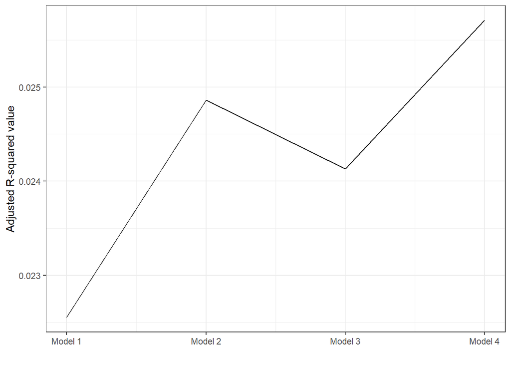

```r
ModelFit <- tibble(model = c(1, 2, 3, 4),
                   R_square = c(summary(model1)$adj.r.squared,
                                summary(model2)$adj.r.squared,
                                summary(model3)$adj.r.squared,
                                summary(model4)$adj.r.squared))

ggplot(ModelFit, aes(x = model, y = R_square)) +
  geom_line() +
  scale_x_continuous(name = "",
                   breaks = breaks <- seq(1, 4, by = 1),
                   labels = paste("Model", breaks)) +
  scale_y_continuous(name = "Adjusted R-squared value") +
  theme_bw()
```

It looks like Model 4 is the best fitting model, although the differences are tiny (notice the range of values on the y-axis). So I’ll call Model 4 my preferred model.

I can use the `export_summs()` function to create a nicely-formatted table showing the results of multiple models side-by-side. Note that I’m leaving the intercept out of the table because it doesn’t tell us anything interesting.

```r
coeff_names <- c("Weekly work hours" = "WKHP",
                 "Annual income" = "PINCP",
                 "Annual income\n(log-transformed)" =
                   "log(PINCP)",
                 "Male\n(compared to female)" = "SEX_labelMale",
                 "Group quarters\n(compared to owned home)" =
                   "tenureGroup quarters",
                 "Rented home\n(compared to owned home)" =
                   "tenureRent",
                 "Rent-free home\n(compared to owned home)" =
                   "tenureRent-free",
                 "Interaction:\nmale and log-transformed income" =
                    "log(PINCP):SEX_labelMale",
                 "Interaction:\nmale and work hours" =
                    "WKHP:SEX_labelMale",
                 "Interaction:\nmale and group quarters" =
                    "tenureGroup quarters:SEX_labelMale",
                 "Interaction:\nmale and group quarters" =
                    "tenureRent:SEX_labelMale",
                 "Interaction:\nmale and group quarters" =
                    "tenureRent-free:SEX_labelMale")

export_summs(model1, model4,
             error_format = "(p = {p.value})",
             error_pos = "same",
             model.names = c("Initial model", "Preferred model"),
             coefs = coeff_names)
```

|  | Initial model | Preferred model |
| --- | --- | --- |
| Weekly work hours | 0.16 *** (p = 0.00) | 0.05 *** (p = 0.00) |
| Annual income | 0.00 *** (p = 0.00) |  |
| Annual income (log-transformed) |  | 1.88 *** (p = 0.00) |
| Male (compared to female) | 2.94 *** (p = 0.00) | 10.56 *** (p = 0.00) |
| Group quarters (compared to owned home) | -11.19 *** (p = 0.00) | -7.60 *** (p = 0.00) |
| Rented home (compared to owned home) | -2.71 *** (p = 0.00) | -1.70 *** (p = 0.00) |
| Rent-free home (compared to owned home) | -3.62 *** (p = 0.00) | -2.02 * (p = 0.02) |
| Interaction: male and log-transformed income |  | -1.10 *** (p = 0.00) |
| Interaction: male and work hours |  | 0.10 *** (p = 0.00) |
| Interaction: male and group quarters |  | -4.50 *** (p = 0.00) |
| N | 115183 | 115183 |
| R2 | 0.02 | 0.03 |
| *** p < 0.001; ** p < 0.01; * p < 0.05. |  |  |

## Visualizing regression results

Let’s visualize some of the relationships from our preferred model. Here’s a chart showing the 95-percent confidence intervals for the coefficents of each of our model coefficients.

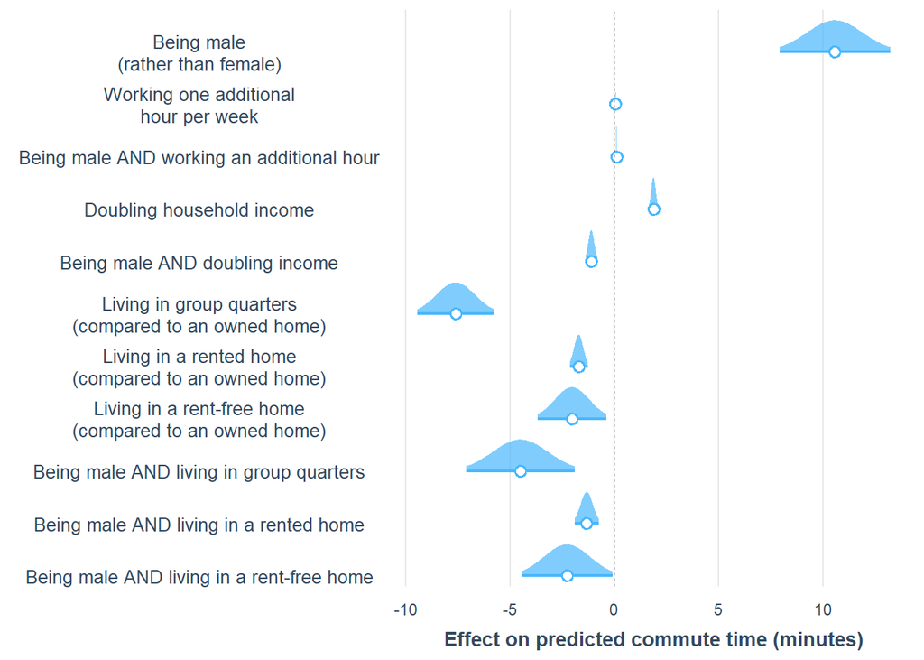

```r
coeff_desc <- c("Being male AND living in a rent-free home" =
                         "tenureRent-free:SEX_labelMale",
                 "Being male AND living in a rented home" =
                         "tenureRent:SEX_labelMale",
                 "Being male AND living in group quarters" =
                         "tenureGroup quarters:SEX_labelMale",
                "Living in a rent-free home\n(compared to an owned home)" =
                         "tenureRent-free",
                 "Living in a rented home\n(compared to an owned home)" =
                         "tenureRent",
                 "Living in group quarters\n(compared to an owned home)" =
                         "tenureGroup quarters",
                "Being male AND doubling income" =
                         "log(PINCP):SEX_labelMale",
                 "Doubling household income" =
                         "log(PINCP)",
                "Being male AND working an additional hour" =
                         "WKHP:SEX_labelMale",
                 "Working one additional\nhour per week" = "WKHP",
                "Being male\n(rather than female)" = "SEX_labelMale")

plot_coefs(model4,
           coefs = coeff_desc,
           plot.distributions = TRUE,
           rescale.distributions = TRUE) +
  scale_x_continuous(name = "Effect on predicted commute time (minutes)")
```

Here is the predicted relationship between income and commute time, for both men and women, holding all other variables at their means.

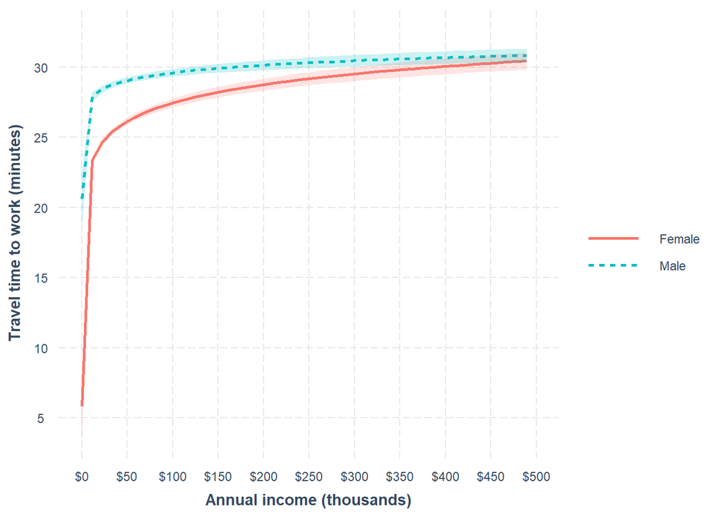

```r
interact_plot(model4, pred = PINCP, modx = SEX_label, interval = TRUE) +
  scale_x_continuous(name = "Annual income (thousands)",
                     limits = c(0, 500000),
                     breaks = breaks <- seq(0, 500000, by = 50000),
                     labels = paste("$",
                                    prettyNum(breaks/1000, big.mark = "'"),
                                    sep = "")) +
  scale_y_continuous(name = "Travel time to work (minutes)",
                     breaks = seq(0, 45, by = 5)) +
  scale_color_discrete(name = "") +
  scale_linetype_discrete(name = "") +
  scale_fill_discrete(name = "")
```

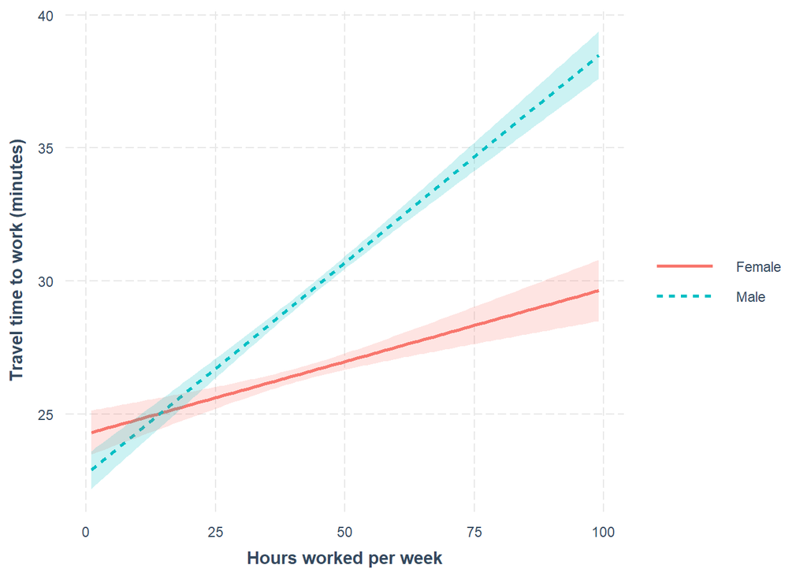

```r
interact_plot(model4, pred = WKHP, modx = SEX_label, interval = TRUE) +
  scale_x_continuous(name = "Hours worked per week") +
  scale_y_continuous(name = "Travel time to work (minutes)",
                     breaks = seq(0, 45, by = 5)) +
  scale_color_discrete(name = "") +
  scale_linetype_discrete(name = "") +
  scale_fill_discrete(name = "")
```

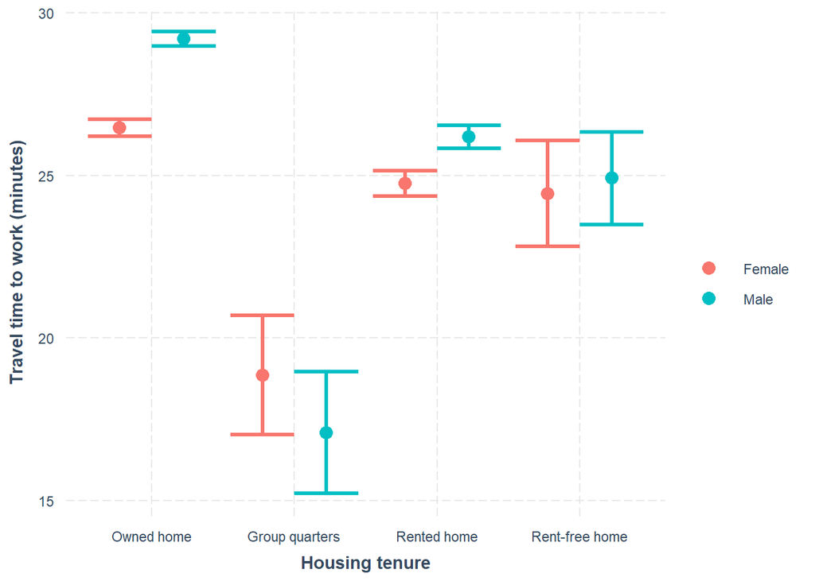

```r
cat_plot(model4, pred = tenure, modx = SEX_label, interval = TRUE) +
 scale_x_discrete(name = "Housing tenure",
                    labels = c("Owned home", "Group quarters",
                               "Rented home", "Rent-free home")) +
  scale_y_continuous(name = "Travel time to work (minutes)",
                     breaks = seq(0, 45, by = 5)) +
  scale_color_discrete(name = "") +
  scale_linetype_discrete(name = "") +
  scale_fill_discrete(name = "")
```